# Script used for tartessos analysis explained step by step.

Ana Belén Romero-Losada, Francisco J. Romero-Campero

Feb, 2021

## Used packages.

Load the packages that are used in this script. Several Bioconductor packages are used, such as *ballgown* and *limma* packages for reading the transcriptomic data and for executing the differential expression analysis, or *clusterProfiler* and *pathview* for performing enrichment analyses in GO terms and metabolic pathways in KEGG, respectively.

```r
library(ballgown)
library(limma)
library(clusterProfiler)
library(pathview)
```

Additionally, two CRAN packages are required for executing this script: ggplots and seqinr. Ggplots will be used to generate certain plots and seqinr is required to work with biological sequences.

```r
library(gplots)
library(seqinr)
```

Finally, the annotation packages included in tartessos_RNAseq github folder need to be installed and loaded before starting the analysis.

```r
install.packages("packages/org.Hlacustris.eg.db",repos = NULL)
install.packages("packages/TxDb.Hlacustris.NCBI",repos = NULL)
library(org.Hlacustris.eg.db)
library(TxDb.Hlacustris.NCBI)
```

## Load genome sequence data

Sequences and their names will be extracted from *haematococcus_lacustris.fa* which contains the sequenced genome of **Haematococcus lacustris**.

```r
hlacustris.info <- read.fasta(file = "haematococcus_lacustris.fa",seqtype = "DNA")
hlacustris.seqs <- getSequence(hlacustris.info)
names(hlacustris.seqs) <- getName(hlacustris.info)
```

Gene names are extracted from TxDb package and all the information is gathered in the same data frame.

```r
txdb <- TxDb.Hlacustris.NCBI
hlacustris.genes <- as.data.frame(genes(txdb))
```

## Differential expression analysis.

Before starting the analysis, gene expression data has to be loaded.

```r
gene.expression.data <- read.table(file = "gene_expression.tsv",header = T,sep = "\t")
gene.expression <- as.matrix(gene.expression.data[,2:5])
rownames(gene.expression) <- gene.expression.data$Gene
log.gene.expression <- log2(gene.expression+1)
head(log.gene.expression)
```

```
##             NO3_2mM_1 NO3_2mM_2 NO3_15mM_1 NO3_15mM_2
## HaLaN_00003  0.000000         0  0.6139493   2.123315
## HaLaN_00005  0.000000         0  1.7130755   1.865608
## HaLaN_00008  0.000000         0  1.6028255   2.455171
## HaLaN_00009  0.000000         0  0.8113765   0.000000
## HaLaN_00011  0.000000         0  1.8119366   2.555839
## HaLaN_00013  6.264777         0  5.6582149   5.550431
```

The first step in a differential expression analysis is the specification of the experimental design. It is indicated in a factorial way, meaning that the first condition is represented by the number 1 and the second one by the number 2. In that way, for example, there are as many 1 as there are replicates of the first condition.

```r
factor.experimental.design <- c(1,1,2,2)
limma.experimental.design <- model.matrix(~ -1+factor(factor.experimental.design))
colnames(limma.experimental.design) <- c("NO3_2mM", "NO3_15mM")
```

Then, the stimated gene expression levels of each gene are adjusted to a linear model (using the **lmFit** function included in *limma*) considering the experimental design specificated.

```r
linear.fit <- lmFit(log.gene.expression, limma.experimental.design)
```

The contrast that will be performed is indicated using **makeContrast** function, and the fold change and p-value are calculated with the functions **constrasts.fit** and **eBayes**.

```r
contrast.matrix <- makeContrasts(NO3_2mM-NO3_15mM,
                                 levels=c("NO3_2mM", "NO3_15mM"))

contrast.linear.fit <- contrasts.fit(linear.fit, contrast.matrix)
contrast.results <- eBayes(contrast.linear.fit)
```

Finally, using the **topTable** function, the results from the differential expressed genes analysis can be extracted.

```r
degs.results <- topTable(contrast.results, number=nrow(log.gene.expression),coef=1,sort.by="logFC")
head(degs.results)
```

```
##                 logFC  AveExpr         t      P.Value   adj.P.Val        B
## HaLaN_24436  13.63733 6.818664  59.89627 1.681870e-05 0.001794045 2.667307
## HaLaN_29182 -12.49526 6.247632 -54.58180 2.190424e-05 0.001794045 2.614359
## HaLaN_22481  12.29575 6.147877  71.75183 1.006331e-05 0.001794045 2.748734
## HaLaN_10625 -12.21961 6.109806 -78.94999 7.667461e-06 0.001794045 2.782310
## HaLaN_06589 -11.65937 5.829685 -49.87953 2.829837e-05 0.001794045 2.554519
## HaLaN_06588 -11.26458 5.632292 -51.47007 2.588252e-05 0.001794045 2.576384
```

To interpret the results in a easier way, the activated and repressed genes can be identificated considering a q-value and fold change treshold. In this case, the fold change treshold selected is 2 and the q-value treshold is 0.05.

```r
fold.change <- degs.results$logFC
q.values <- degs.results$adj.P.Val
genes.ids <- rownames(degs.results)

names(fold.change) <- genes.ids
names(q.values) <- genes.ids

fc.threshold <- 2
q.val.threshold <- 0.05

activated.genes <- genes.ids[fold.change > log2(fc.threshold) & q.values < q.val.threshold]
repressed.genes <- genes.ids[fold.change < - log2(fc.threshold) & q.values < q.val.threshold]

length(activated.genes)
```

```
## [1] 414
```

```r
length(repressed.genes)
```

```
## [1] 5348
```

Considering the selected tresholds, the number of activates genes is 414 and the number of repressed genes is 5348. This results can be represented in a volcano plot.

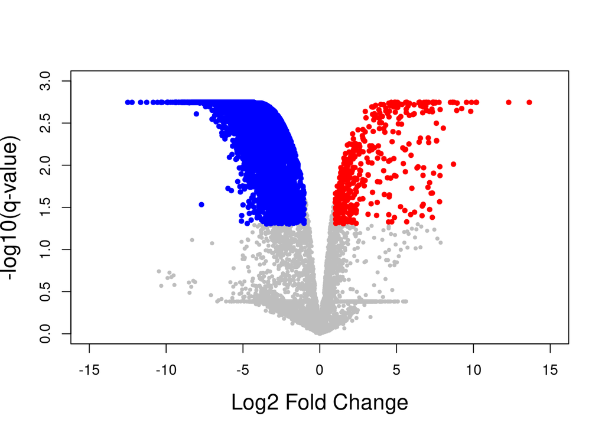

```r
log10.qval <- -log10(q.values)

plot(fold.change,log10.qval,pch=19,cex=0.5,col="grey",
     xlim=c(-15,15), ylim=c(0,3),
     xlab="Log2 Fold Change", ylab="-log10(q-value)",cex.lab=1.5)
points(fold.change[activated.genes],log10.qval[activated.genes],cex=0.7,col="red",pch=19)
points(fold.change[repressed.genes],log10.qval[repressed.genes],cex=0.7,col="blue",pch=19)
```

## Correspondence between genome notation and NCBI notation.

Genome notation doesn’t match with NCBI notation, which can lead to confusion at some steps of the analysis.

```r
halan.gfh.correspondence <- read.table(file="gfh_halan_correspondence.tsv",sep="\t",as.is=T)
head(halan.gfh.correspondence)
```

```
##             V1           V2
## 1     GFH05524  HaLaN_00001
## 2 HaLaN_t00001 HaLaN_t00001
## 3     GFH05525  HaLaN_00002
## 4     GFH05526  HaLaN_00003
## 5     GFH05527  HaLaN_00004
## 6     GFH05528  HaLaN_00005
```

```r
halan <- halan.gfh.correspondence$V2
gfh <- halan.gfh.correspondence$V1
names(halan) <- gfh
names(gfh) <- halan
```

## KEEG pathway enrichment

KO ids are extracted from *org.Hlacustris.eg.db*.

```r
hlac.ko <- select(org.Hlacustris.eg.db,columns = c("KO"),keys=keys(org.Hlacustris.eg.db,keytype = "GID"))
ko.universe <- hlac.ko$KO
ko.universe <- ko.universe[!is.na(ko.universe)]
```

Activated and repressed genes are gathered with their corresponding KO id.

```r
activated.target.ko <- subset(hlac.ko,GID %in% gfh[activated.genes])$KO
activated.target.ko <- activated.target.ko[!is.na(activated.target.ko)]

repressed.target.ko <- subset(hlac.ko,GID %in% gfh[repressed.genes])$KO
repressed.target.ko <- repressed.target.ko[!is.na(repressed.target.ko)]
```

Now the enrichment can be achieved using the **enrichKEGG** function included in *pathway* package. The results are represented in a simple barplot. Additionally, the results can be saved in a **.txt** file.

```r
pathway.enrichment <- enrichKEGG(gene = activated.target.ko, organism = "ko",
                                 universe = ko.universe,qvalueCutoff = 0.05)
```

```
## Reading KEGG annotation online:
##
## Reading KEGG annotation online:
```

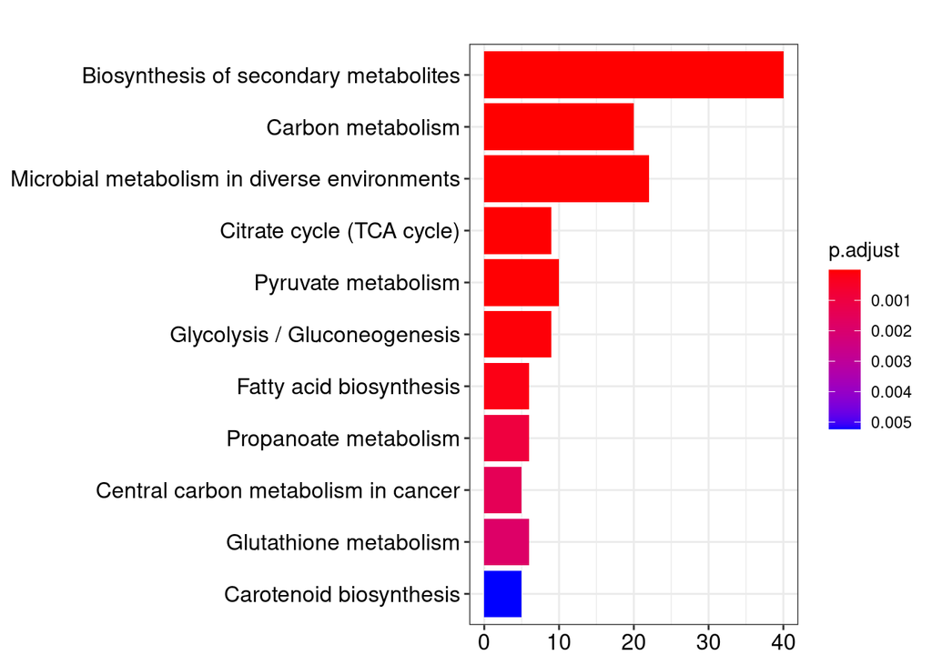

```r
barplot(height = pathway.enrichment,showCategory = 11)
```

```r
write.table(x = as.data.frame(pathway.enrichment),
            file = "pathway_enrichment/pathway_activated.tsv",
            quote = F,sep = "\t",row.names = F)
```

### Graphical representation of pathways

At first place, a new variable called *genes.pathway* is defined. Each element of this variable correspond to a different gene and it will contain a different number depending on whether or not that gene is activated. The value -1 will be given to repressed genes, +1 to activated ones and 0 to neutral ones.

```r
genes.pathway <- rep(0, length(ko.universe))
names(genes.pathway) <- ko.universe

genes.pathway[activated.target.ko] <- 1
genes.pathway[repressed.target.ko] <- -1
```

Then this variable can be used to generate the desirable KEGG pathway (for example ko00906) where the enzimes that correspond to activated and repressed genes will be colored differently.

```r
pathview(gene.data = sort(genes.pathway,decreasing = TRUE),
         kegg.dir ="pathway_enrichment/", pathway.id = "ko00906",
         species = "ko",
         limit = list(gene=max(abs(genes.pathway)), cpd=1))
```

```
## Note: Only KEGG ortholog gene ID is supported, make sure it looks like "K01488"!
```

```
## Note: Mapping via KEGG gene ID (not Entrez) is supported for this species,
## it looks like "K01488"!
```

```
## Info: Working in directory /home/ana/Escritorio/tartessos_analysis
```

```
## Info: Writing image file ko00906.pathview.png
```

## Identification of transcription factors and promoter sequences.

### Identification of transcription factor genes aspirants.

In order to make the analysis easier, a simple function is created to extract the genes which PFAM id match with the target one.

```r
extract.tf <- function(annotation, pfam.id)
{
  return(unique(subset(annotation,PFAM == pfam.id)$GENES))
}
```

The PFAM ids that correspond to each gene are gathered in the annotation file, so it needs to be loaded.

```r
haematococcus.annotation <- read.table(file = "haematoccocus_functional_annotation.csv",
                                       header = T,as.is = T,fill = T)
```

Then, the PFAM corresponding to the the target transcription factor is searched manually. For example, PF00847 corresponds the AP2 transcription factors family, so it is used to find the genes inside haematococcus genome that can belong to this family.

```r
AP2.genes <- extract.tf(annotation = haematococcus.annotation,pfam.id = "PF00847")
AP2.genes
```

```
##  [1] "GFH06548" "GFH10653" "GFH11227" "GFH13162" "GFH13933" "GFH14776"
##  [7] "GFH20945" "GFH21289" "GFH23208" "GFH24654" "GFH25442"
```

```r
length(AP2.genes)
```

```
## [1] 11
```

However, it can also be interesting to find out if any of the AP2 transcription factors family aspirants genes is activated or repressed under our experiment conditions.

```r
ap2.activated <- length(intersect(activated.genes, halan[AP2.genes]))
ap2.repressed <- length(intersect(repressed.genes, halan[AP2.genes]))
ap2.non.diff <- length(AP2.genes) - ap2.activated - ap2.repressed
```

This analysis is executed to all the possible transcription factors families.

## Extraction of promoter sequences of targets genes.

The following function is used to achieve that goal. To a given list of gene names, it extracts their promoter sequences (1000 bp upstream from TSS) using the sequenced genome.

```r
promoter.sequence <- function(genes.names, #Halan gene name
                              genes.info, # Gene info variable created before
                              genome.seqs, #genome seqs variable created before
                              file.name) #Output name
{
  genes.of.interest <- subset(genes.info, gene_id %in% genes.names)

  promoter.seqs <- vector(mode="list",length=nrow(genes.of.interest))
  names(promoter.seqs) <- genes.of.interest$gene_id

  for(i in 1:nrow(genes.of.interest))
  {
    current.seq.id <- as.character(genes.of.interest$seqnames[i])
    current.seq <- genome.seqs[current.seq.id]
    current.strand <- as.character(genes.of.interest$strand[i])

    if(current.strand == "+")
    {
      tss <- genes.of.interest$start[i]
      if(tss > 1000)
      {
        promoter.seqs[[i]] <-current.seq[[1]][(tss-1000):(tss-1)]
      } else
      {
        promoter.seqs[[i]] <-current.seq[[1]][1:(tss-1)]
      }

    } else if (current.strand == "-")
    {
      tss <- genes.of.interest$end[i]
      promoter.seqs[[i]] <- comp(rev(current.seq[[1]][(tss+1):(tss+1000)]))
    }
  }

  write.fasta(sequences = promoter.seqs,
              names = names(promoter.seqs),
              file.out = file.name)
  return(promoter.seqs)
}
```

For example, it was used with the carotenoids biosynthesis key enzime genes.

```r
carotenoids.genes <- c("HaLaN_05222", "HaLaN_06917", "HaLaN_19207", "HaLaN_29333", "HaLaN_01499", "HaLaN_15035",
                       "HaLaN_05151", "HaLaN_15758", "HaLaN_04875")

carotenoids.promoters <- promoter.sequence(genes.names = carotenoids.genes,
                        genes.info = hlacustris.genes ,
                        genome.seqs = hlacustris.seqs,
                        file.name ="carotenoids_promoters.fa")
```

## Functions for for specific pathways analysis.

### Barplots

Two different functions were created in order to generate barplots representing the expression level of specific genes in both conditions. One of them, receive as input the genome notation type name of the target gene.

```r
barplot.halan.gene <- function(gene.id, #Halan name of target gene
                               gene.expression) #gene expression matrix
{
  #Extract the mean expression level of the target gene
    expression.mean.2mM <- mean(unlist(gene.expression[gene.id,
                                                   c("NO3_2mM_1", "NO3_2mM_2")]))
    expression.mean.15mM <- mean(unlist(gene.expression[gene.id,
                                                    c("NO3_15mM_1", "NO3_15mM_2")]))
    means <- c(expression.mean.15mM,expression.mean.2mM)
  #Extract the standard deviation
    expression.sd.2mM <- sd(unlist(gene.expression[gene.id,
                                               c("NO3_2mM_1", "NO3_2mM_2")]))
    expression.sd.15mM <- sd(unlist(gene.expression[gene.id,
                                                c("NO3_15mM_1", "NO3_15mM_2")]))
    sds <- c(expression.sd.15mM,expression.sd.2mM)

  #Generate a png file containing the resulting barplot
    #png(filename = paste0(gene.id,".png"),width = 300)
    #par(lwd=3)
    xpos <- barplot(means,col=c("springgreen4","firebrick2"),
                    names.arg = c("15mM","2mM"),las=2,cex.names = 1.5,
                    ylim=c(0,max(means+sds)*1.2),cex.axis = 1.5,lwd=3,
                    main=gene.id,
                    cex.main=2)
    arrows(x0 = xpos,y0 = means + sds, x1 = xpos, y1 = means - sds,length = 0.1,
           code = 3,angle=90,lwd=2)
    #dev.off()
}
```

The gene **HaLaN_03814** can be used as an example.

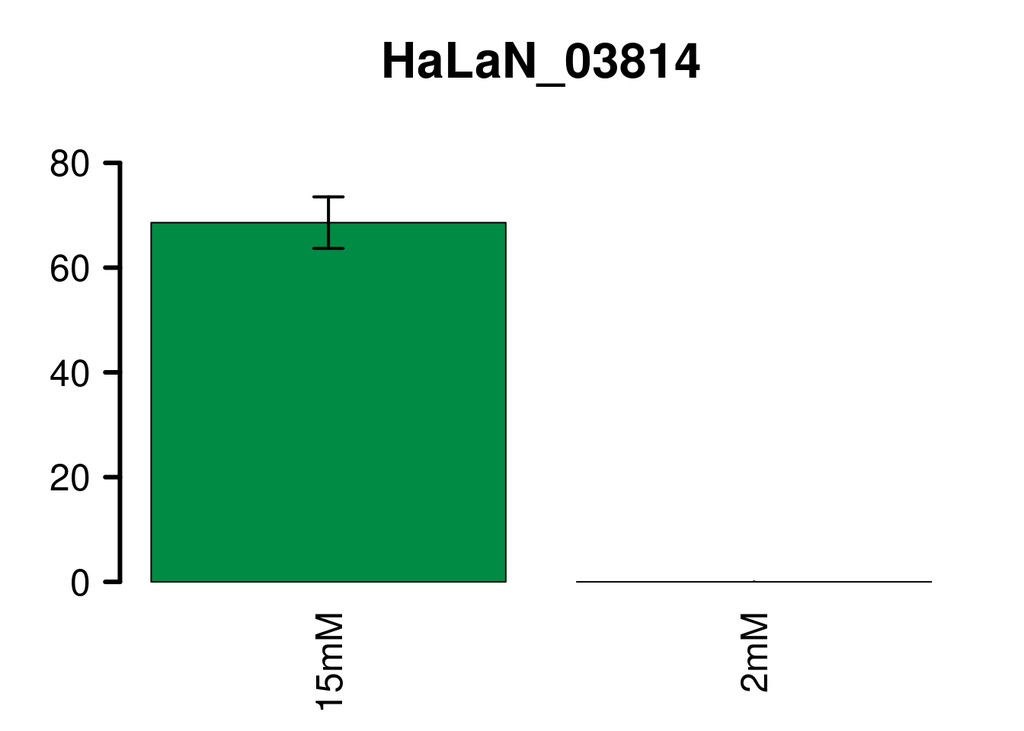

```r
barplot.halan.gene(gene.id="HaLaN_03814",gene.expression=gene.expression)
```

However, the other one receive as input the KO id of a target enzyme. If the KO id is related to several genes, it will generate a different barplot for each of them. Previously, a variable containing all the Haematococcus genes with their related KO ids needs to be created. This data can be extracted from the **org.Hlacustris.eg.db** package.

```r
hlacustris.ko <- select(org.Hlacustris.eg.db,columns = c("GID","KO"),
                        keys=keys(org.Hlacustris.eg.db,keytype = "GID"))
```

```r
barplot.enzyme.ko <- function(ko, #KO of target enzyme
                              enzyme.name, #Name that will appear in output
                              map.gfh.halan, #halan variable
                              gene.expression, #gene expression matrix
                              hlacustris.ko, #KO ids vs gene names variable created before
                              gene.name) #Name that will appear in output

{
  #find the genes related to the target KO
  halan.gene.names <- intersect(map.gfh.halan[subset(hlacustris.ko,KO == ko)$GID],
                                rownames(gene.expression))
  #For each gene, extract mean expression level, extract sd values and generate a barplot.
  for(i in 1:length(halan.gene.names))
  {
    enzyme.mean.2mM <- mean(unlist(gene.expression[halan.gene.names[i],
                                                   c("NO3_2mM_1", "NO3_2mM_2")]))
    enzyme.mean.15mM <- mean(unlist(gene.expression[halan.gene.names[i],
                                                    c("NO3_15mM_1", "NO3_15mM_2")]))
    means <- c(enzyme.mean.15mM,enzyme.mean.2mM)

    enzyme.sd.2mM <- sd(unlist(gene.expression[halan.gene.names[i],
                                               c("NO3_2mM_1", "NO3_2mM_2")]))
    enzyme.sd.15mM <- sd(unlist(gene.expression[halan.gene.names[i],
                                                c("NO3_15mM_1", "NO3_15mM_2")]))
    sds <- c(enzyme.sd.15mM,enzyme.sd.2mM)


    #png(filename = paste(c(enzyme.name,i,".png"),collapse=""),width = 300)
    #par(lwd=3)
    xpos <- barplot(means,col=c("springgreen4","firebrick2"),
                    names.arg = c("15mM","2mM"),las=2,cex.names = 1.5,
                    ylim=c(0,max(means+sds)*1.2),cex.axis = 1.5,lwd=3,
                    main=paste(gene.name,halan.gene.names[i],sep = " - "),
                    cex.main=2)
    arrows(x0 = xpos,y0 = means + sds, x1 = xpos, y1 = means - sds,length = 0.1,
           code = 3,angle=90,lwd=2)
    #dev.off()
  }

  return(halan.gene.names)
}
```

Phytoene synthase enzyme can be used as an example:

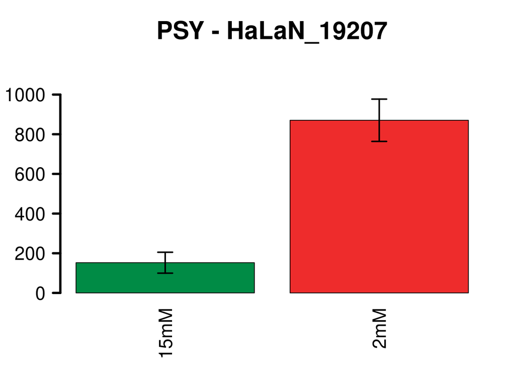

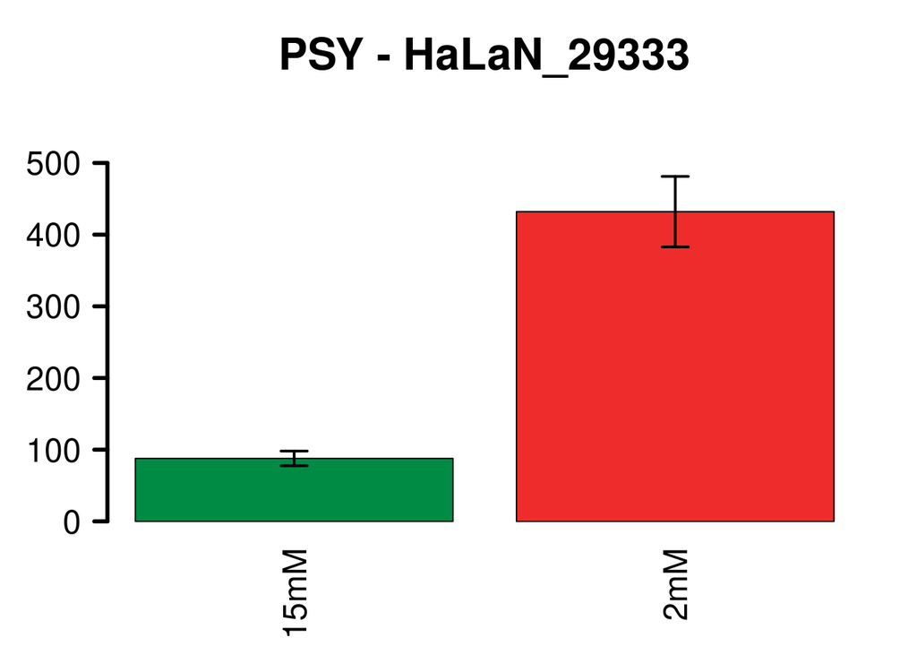

```
## [1] "HaLaN_19207" "HaLaN_29333"
```

```r
barplot.enzyme.ko(ko="K02291",enzyme.name = "0_PS", map.gfh.halan = halan,
                  gene.expression = gene.expression,gene.name="PSY",
                  hlacustris.ko=hlacustris.ko)
```

### Heatmaps.

Heatmaps were created to show the expression level of each enzyme represented in the figures included in the final paper. The function used to generate them recieve as input the KO id of a desirable enzyme and, as the **barplot.enzyme.ko** function does, it will generate a different heatmap for each gene related to the target KO.

```r
heatmap.enzyme.ko <- function(ko, #KO id of the target enzyme
                              enzyme.name, #Name that will appear in output
                              map.gfh.halan, #halan variable
                              gene.expression, #gene expression matrix
                              precision)

{
  #determine the color gradient from positive to negative values
  pos.colfunc <- colorRampPalette(c("white","firebrick2"))
  pos.colors <- pos.colfunc(precision)

  neg.colfunc <- colorRampPalette(c("white","springgreen4"))
  neg.colors <- neg.colfunc(precision)

  #find the genes related to the target KO id.
  halan.gene.names <- intersect(map.gfh.halan[subset(hlacustris.ko,KO == ko)$GID],rownames(gene.expression))

  #Choose min. and max. values of fc.
  fc.max <- 0
  fc.min <- 20

  #for each gene related to the target KO..
  for(i in 1:length(halan.gene.names))
  {
    #extract its mean expression level
    enzyme.mean.2mM <- mean(unlist(gene.expression[halan.gene.names[i],c("NO3_2mM_1", "NO3_2mM_2")]))
    enzyme.mean.15mM <- mean(unlist(gene.expression[halan.gene.names[i],c("NO3_15mM_1", "NO3_15mM_2")]))
    #calculate fc
    fc <- enzyme.mean.2mM/enzyme.mean.15mM
    #adjust the color gradient level
    if(fc >= 1)
    {
      if(fc >= fc.max)
      {
        fc.max <- fc
      }

      if(round(fc*10) < precision)
      {
        cols <- pos.colors[round(fc*10)]
      } else
      {
        cols <- pos.colors[precision]
      }

    } else
    {
      if(fc <= fc.min)
      {
        fc.min <- fc
      }

      if(round(10/fc) < precision)
      {
        cols <- neg.colors[round(10/fc)]
      } else
      {
        cols <- neg.colors[precision]
      }

    }

    #Generate the heatmap
    #png(filename = paste(c("heatmap_",enzyme.name,i,".png"),collapse=""))
    plot(x=0,y=0,col="white",axes=F,xlab="",ylab="",ylim=c(0,10),xlim=c(0,10))
    polygon(x = c(2,8,8,2),y=c(2,2,8,8),lwd=6,col = cols)
   # dev.off()
  }

  return(list(halan.gene.names,fc.max, fc.min, 1/fc.min))
}
```

Once again, phytoene synthase will be used as an example:

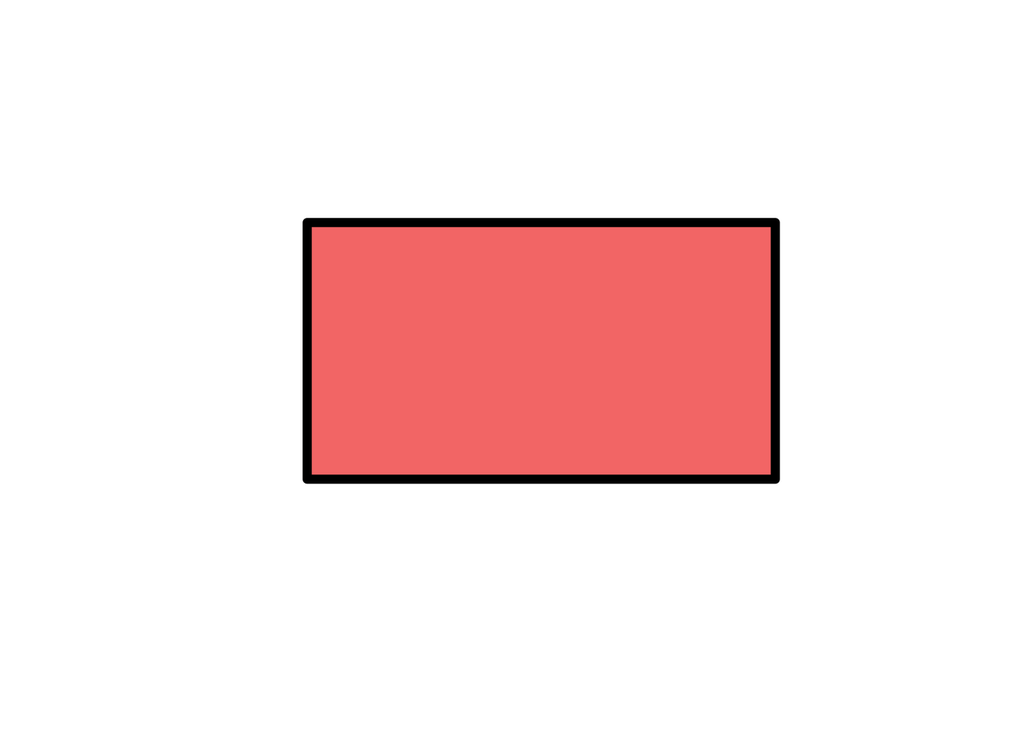

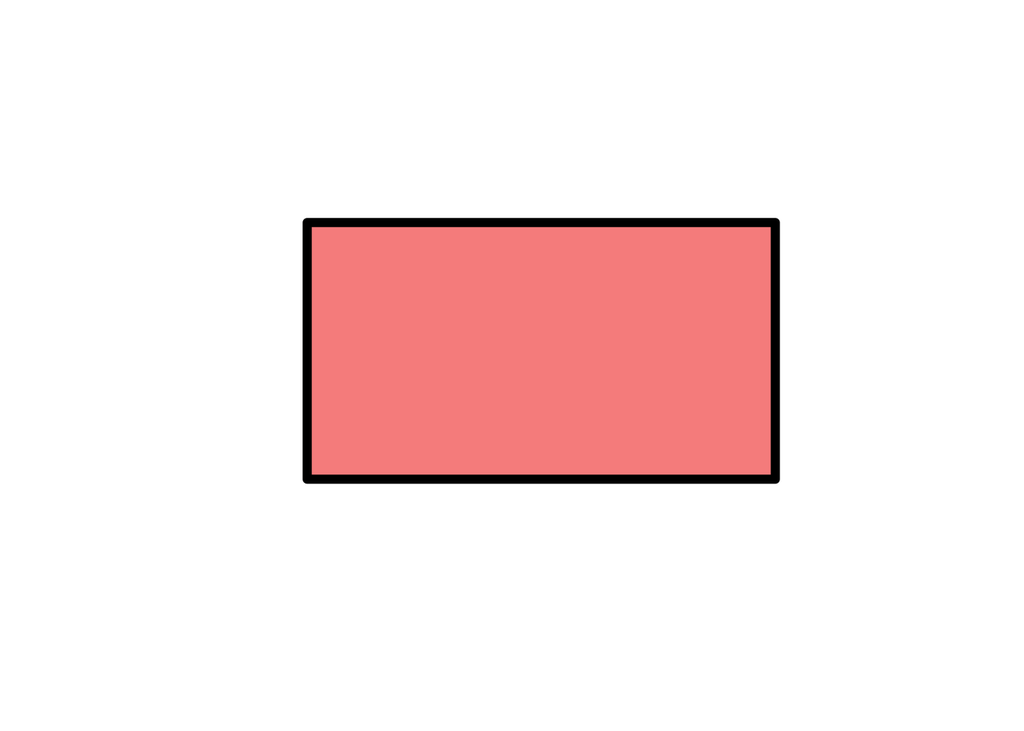

```
## [[1]]
## [1] "HaLaN_19207" "HaLaN_29333"
##
## [[2]]
## [1] 5.711013
##
## [[3]]
## [1] 20
##
## [[4]]
## [1] 0.05
```

```r
heatmap.enzyme.ko(ko="K02291",enzyme.name = "0_PS", map.gfh.halan = halan,
                  gene.expression = gene.expression,
                  precision = 78)
```